# The Ohio Supercomputer Center (OSC)

Week 2 – Lecture A – accompanying lecture notes

Author

Affiliations

Jelmer Poelstra

[CFAES Bioinformatics Core, Ohio State University](https://go.osu.edu/bioinformatics-core)

[Dept. of Plant Pathology, Ohio State University](https://plantpath.osu.edu)

Published

August 22, 2026

Modified

[figure not shown]

## 1 Home directory clarifications and pitfalls

Many new OSC users are confused about the Home directory, so let’s clarify a few things:

- Even though a project number is part of the path to your Home directory (e.g., `/users/PAS3454/jane`), this is merely an OSC naming convention and your Home directory is not really tied to any OSC Project. (This also means, for example, that your Home directory will remain the same even if you are removed from a project, or a project stops existing.)
- By default, you will be in your Home directory after logging in to OSC. But this is typically not where you want to be when working with data and running analyses.
- Avoid storing research project files in your Home dir: it has limited space and is harder to access by collaborators.
- Your Home dir will contain some automatically generated files and those should generally not be deleted!

We’ll talk more about this in week 5 of the course!

## 2 The Clusters menu

### 2.1 System Status

In the “**Clusters**” dropdown menu, click on the item at the bottom, “**`System Status`**”:

[figure not shown]

*The Clusters dropdown menu*

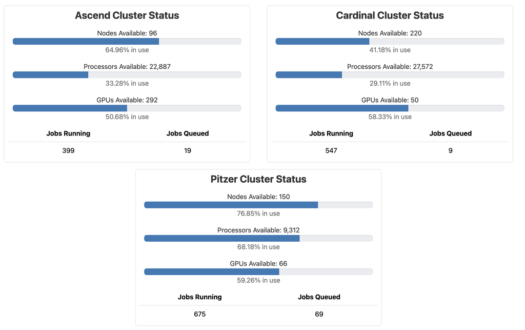

A screenshot of the “System Status” page showing live cluster usage.

### 2.2 Direct Unix shell access

Interacting with a supercomputer is most commonly done using a so-called “Unix shell”, which is a command-line interface to a computer that you’ll use throughout the course. Still under the **Clusters** dropdown menu (see the screenshot above), you can access a Unix shell on Ascend, Cardinal, or Pitzer.

If you click `Cardinal Shell Access`, a new browser tab will open where the bottom of the page looks like this:

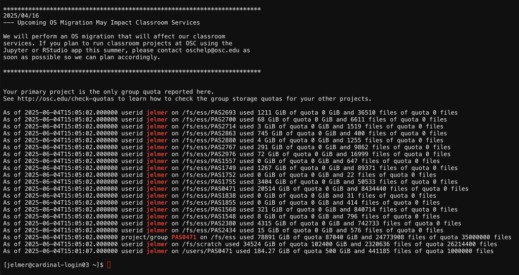

A Unix shell on the Cardinal cluster as accessed through OSC OnDemand. OSC prints some information like file usage quota, and at the bottom of the screen is the prompt where you can type commands.

During the course, you will instead access a Unix shell via the Code Server Interactive App. Still, the abovementioned method can occasionally be useful as a more rapid access point.

Back to top